# Ford GoBike System Data

## by Mennat-Allah Mustapha

## Investigation Overview

> Take a look back through the past period to know the users better and know the usage patterns

> such as :
> - When most trips are taken in terms of time of day, day of the week
> - average trip time
> - Does the above depend on user age / gender or if the user is a subscriber or customer or age?
> - most visted stations

## Dataset Overview

> The dataset records 183412 entries(trips). the system has 4646 bikes and 329 stations. There are some missing data in members' coloumns (gender and birthyear)

## Average rides time in minutes

> Most rides durations are less than 20 mins specificaly around 10 mins. but there are exceptional rides exceeded 100 min and few that have between 40 and 80 mins

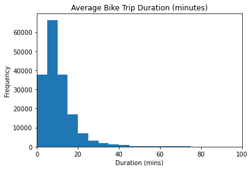

```python
bin_edges = np.arange(0, df2['duration_min'].max()+5 , 5)
plt.hist(data = df2 , x = 'duration_min' , bins = bin_edges);
plt.xlim(0,100);
plt.xlabel('Duration (mins)');
plt.ylabel("Frequency");
plt.title('Average Bike Trip Duration (minutes)');
```

## Number of rides per day

> Most rides happen on day(3) which is Thursday and less rides happen on days (5,6) which are Saturday and Sunday by mostly equal frequency Days of uasage don't differ much from males to females, Thursday still the most day with rides

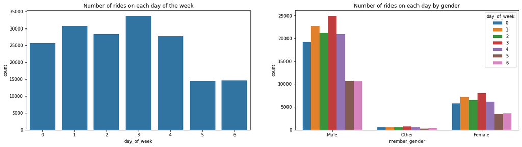

```python
# have two plots side-by-side
# Set a larger figure size for subplots
plt.figure(figsize = [20, 5])

plt.subplot(1, 2, 1) # 1 row, 2 cols, subplot 1

df2['day_of_week'] = pd.DatetimeIndex(df2['start_time']).weekday
base_color=sb.color_palette()[0]
sb.countplot(data = df2 , x = 'day_of_week' , color = base_color);
plt.title('Number of rides on each day of the week');

#see if number of rides on different days depends on gender
plt.subplot(1, 2, 2)
plt.title('Number of rides on each day by gender')
sb.countplot(data = df2, x = 'member_gender', hue = 'day_of_week');
```

## During the day, users follow a remarkable pattern

> Most rides happen in the morning and the evening, which makes sense beacuase these are the rush hours in the day

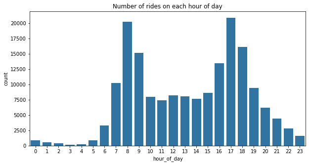

```python
#getting number of rides per hour during the days
df2['hour_of_day'] = pd.DatetimeIndex(df2['start_time']).hour
df2.head(1)
plt.figure(figsize=(10,5))
sb.countplot(data = df2 , x = 'hour_of_day' , color = base_color);
plt.title('Number of rides on each hour of day');
```

## How the average trip time is affected by gender and age

> Younger users (between 20 and 40 years old) take longer rides as well as most of them are males

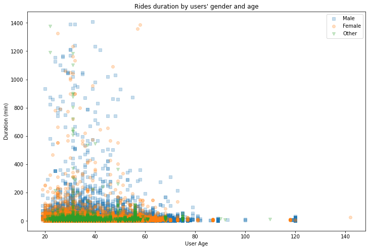

```python
# Finding out how the average trip time is affected by gender and age
gender_markers = [['Male', 's'],['Female', 'o'],['Other', 'v']]
plt.figure(figsize=(12,8));
for gender, marker in gender_markers:
    df_gender = df2[df2['member_gender'] == gender]
    plt.scatter((df_gender['user_age']), df_gender['duration_min'], marker = marker, alpha=0.25)
plt.legend(['Male','Female','Other']);
plt.xlabel('User Age');
plt.ylabel('Duration (min)');
plt.title("Rides duration by users' gender and age")
plt.show();
```

## Most visited stations

> Station (Market St at 10th st) has most rides as end station with more than 3500 rides but not in the top 10 stations as start station

[figure not shown]

[figure not shown]

```python
plt.figure(figsize =(10,5))
top10_start = df2.start_station_name.value_counts()[1:11].sort_values()
#plot the names on y axis
top10_start.plot(kind = 'barh')
plt.title('Most visited stations (start stations)');

plt.figure(figsize =(10,5))
top10_end = df2.end_station_name.value_counts()[1:11].sort_values()
#plot the names on y axis
top10_end.plot(kind = 'barh')
plt.title('Most visited stations (end stations)');
```